# Working with regular expressions in R

Author

Greg Wray

Published

October 22, 2024

## Background

Learning how to use regular expressions will make your data life much simpler. You can use regular expressions to wrangle, filter, reformat, and analyze data. You can also use regular expressions to manage multiple files at once. We will come back to regular expressions on multiple occasions as we move on to Unix, SQL, and Python.

## Regular expressions

A regular expression is a **search pattern**. In the simplest case, it is simply a sequence of normal characters (letters, numbers, spaces, symbols). This is called a *string literal* because the search pattern is literally the sequence of characters. But the power of regular expressions comes from a set of *meta-characters* that indicate specific patterns. These meta-characters define, for instance, alternative characters to match, how many times the pattern should repeat, where the pattern should occur, and other features. The meta-characters are: `\ ^ $ . | ? * + ( ) [ ] { }`.

To explore how meta-characters work, we will use the `str_view()` function, which returns every line containing a match to the search pattern and highlights the match itself. This function has a very useful optional argument `match`, which you can set to `FALSE` to find the opposite of the search pattern.

To get a sense of how the basic regex meta-characters work, we will start by working with the built-in data set `sentences`. Let’s first get to know these “data”.

```r
head(sentences)
```

```
[1] "The birch canoe slid on the smooth planks."
[2] "Glue the sheet to the dark blue background."
[3] "It's easy to tell the depth of a well."
[4] "These days a chicken leg is a rare dish."
[5] "Rice is often served in round bowls."
[6] "The juice of lemons makes fine punch."
```

```r
length(sentences)
```

```
[1] 720
```

**Including meta-characters as literals within a search pattern.** To search for `^` or any other regex meta-character as a literal character, it needs to be *escaped*. In R the escape sequence is two consecutive backslashes. For instance, to include `^` as a string literal, use `\\^` and to include `\` (backslash), use `\\\`.

```r
# incorrect (unescaped) way to search for "all."
str_view(sentences, "all.")
```

```
 [14] │ Kick the b<all >straight and follow through.
 [18] │ The soft cushion broke the man's f<all.>
 [21] │ The sm<all >pup gnawed a hole in the sock.
 [28] │ The colt reared and threw the t<all >rider.
 [65] │ A sm<all >creek cut across the field.
 [66] │ Cars and busses st<alle>d in snow drifts.
 [74] │ The w<alle>d town was seized without a fight.
[112] │ Leaves turn brown and yellow in the f<all.>
[131] │ A cramp is no sm<all >danger on a swim.
[156] │ The pencils have <all >been used.
[172] │ The child almost hurt the sm<all >dog.
[197] │ The petals f<all >with the next puff of wind.
[204] │ A blue crane is a t<all >wading bird.
[213] │ The fly made its way along the w<all.>
[236] │ Whitings are sm<all >fish caught in nets.
[262] │ Carry the pail to the w<all >and spill it there.
[267] │ High seats are best for footb<all >fans.
[296] │ The heap of f<alle>n leaves was set on fire.
[305] │ She danced like a swan, t<all >and graceful.
[307] │ It is late morning on the old w<all >clock.
... and 25 more
```

```r
# correct way to create a regex containing a meta-character
str_view(sentences, "all\\.")
```

```
 [18] │ The soft cushion broke the man's f<all.>
[112] │ Leaves turn brown and yellow in the f<all.>
[213] │ The fly made its way along the w<all.>
[328] │ The plush chair leaned against the w<all.>
[504] │ The dusty bench stood by the stone w<all.>
[539] │ A thick coat of black paint covered <all.>
[577] │ The brass tube circled the high w<all.>
[630] │ Post no bills on this office w<all.>
```

**Define search patterns containing any character.** Four meta-characters are used to indicate any character: letters, numbers, symbols, and punctuation marks, as well as most non-printing characters (including space and tab); the only common character *not* included is end-of-line (carriage return). These meta-characters are sometimes called “wildcards”, but the term “expansion” is more appropriate. They differ in the length of the “any” portion of the pattern.

The `.` meta-character (dot) defines a position of exactly 1 character that can contain any character except end-of-line.

```r
# experiment with the . meta-character
str_view(sentences, "pen.")             # matches "pena", "pen7", pen%", "pen ", etc.
```

```
 [62] │ Use a <penc>il to write the first draft.
[104] │ O<pen >the crate but don't break the glass.
[113] │ The <penn>ant waved when the wind blew.
[135] │ The glow dee<pene>d in the eyes of the sweet girl.
[156] │ The <penc>ils have all been used.
[221] │ A <penc>il with black lead writes best.
[352] │ Each <penn>y shone like new.
[419] │ The point of the steel <pen >was bent and twisted.
[462] │ Dis<pens>e with a vest on a day like this.
[481] │ The way to save money is not to s<pend> much.
[540] │ The <penc>il was cut to be sharp at both ends.
[588] │ Slide the catch back and o<pen >the desk.
[603] │ There is a strong chance it will hap<pen >once more.
[701] │ O<pen >your book to the first page.
```

```r
str_view(sentences, "pen.", match = FALSE)  # everything except matches
```

```
 [1] │ The birch canoe slid on the smooth planks.
 [2] │ Glue the sheet to the dark blue background.
 [3] │ It's easy to tell the depth of a well.
 [4] │ These days a chicken leg is a rare dish.
 [5] │ Rice is often served in round bowls.
 [6] │ The juice of lemons makes fine punch.
 [7] │ The box was thrown beside the parked truck.
 [8] │ The hogs were fed chopped corn and garbage.
 [9] │ Four hours of steady work faced us.
[10] │ A large size in stockings is hard to sell.
[11] │ The boy was there when the sun rose.
[12] │ A rod is used to catch pink salmon.
[13] │ The source of the huge river is the clear spring.
[14] │ Kick the ball straight and follow through.
[15] │ Help the woman get back to her feet.
[16] │ A pot of tea helps to pass the evening.
[17] │ Smoky fires lack flame and heat.
[18] │ The soft cushion broke the man's fall.
[19] │ The salt breeze came across from the sea.
[20] │ The girl at the booth sold fifty bonds.
... and 686 more
```

```r
str_view(sentences, "p..n")             # . matches spaces
```

```
  [1] │ The birch canoe slid on the smooth <plan>ks.
 [13] │ The source of the huge river is the clear s<prin>g.
 [21] │ The small pu<p gn>awed a hole in the sock.
 [48] │ Hop over the fence and <plun>ge in.
 [71] │ A yacht slid around the <poin>t into the bay.
 [90] │ He lay <pron>e and hardly moved a limb.
 [93] │ A <poun>d of sugar costs more than eggs.
 [94] │ The fin was shar<p an>d cut the clear water.
[113] │ The <penn>ant waved when the wind blew.
[167] │ The office <pain>t was a dull, sad tan.
[203] │ Float the soa<p on> top of the bath water.
[229] │ Rake the rubbish u<p an>d then burn it.
[255] │ The <prin>ce ordered his head chopped off.
[265] │ Gray <pain>t stretched for miles around.
[290] │ Tight curls get lim<p on> rainy days.
[302] │ The <plan>t grew large and green in the window.
[312] │ The peace league met to discuss their <plan>s.
[317] │ Screw the round ca<p on> as tight as needed.
[320] │ Men think and <plan> and sometimes act.
[327] │ Boards will war<p un>less kept dry.
... and 29 more
```

```r
str_view(sentences, "P..n")             # matches are case-sensitive
```

```
[561] │ <Pain>t the sockets in the wall dull green.
```

The `?` meta-character matches 0 or 1 of the preceding character or sub-string.

```r
# experiment with the ? meta-character
str_view(sentences, "rse?")            # matches "rs" and "rse" but not "rsee" or "rseee"
```

```
  [9] │ Four hou<rs> of steady work faced us.
 [27] │ Her pu<rse> was full of useless trash.
 [30] │ Read ve<rse> out loud for pleasure.
 [57] │ March the soldie<rs> past the next hill.
 [62] │ Use a pencil to write the fi<rs>t draft.
 [66] │ Ca<rs> and busses stalled in snow drifts.
 [83] │ There are more than two facto<rs> here.
[108] │ Act on these orde<rs> with great speed.
[121] │ Type out three lists of orde<rs>.
[142] │ Guess the result from the fi<rs>t scores.
[184] │ The third act was dull and tired the playe<rs>.
[200] │ Farme<rs> came in to thresh the oat crop.
[205] │ A fresh start will work such wonde<rs>.
[210] │ Even the wo<rs>t will beat his low score.
[237] │ Some ads serve to cheat buye<rs>.
[249] │ The fi<rs>t worm gets snapped early.
[253] │ Both brothe<rs> wear the same size.
[258] │ Fruit flavo<rs> are used in fizz drinks.
[259] │ These pills do less good than othe<rs>.
[260] │ Canned pea<rs> lack full flavor.
... and 29 more
```

The `*` meta-character matches 0, 1, or more of the preceding character or sub-string.

```r
str_view(sentences, "rse*")            # matches "rs", "rse", "rsee", and "rseee"
```

```
  [9] │ Four hou<rs> of steady work faced us.
 [27] │ Her pu<rse> was full of useless trash.
 [30] │ Read ve<rse> out loud for pleasure.
 [57] │ March the soldie<rs> past the next hill.
 [62] │ Use a pencil to write the fi<rs>t draft.
 [66] │ Ca<rs> and busses stalled in snow drifts.
 [83] │ There are more than two facto<rs> here.
[108] │ Act on these orde<rs> with great speed.
[121] │ Type out three lists of orde<rs>.
[142] │ Guess the result from the fi<rs>t scores.
[184] │ The third act was dull and tired the playe<rs>.
[200] │ Farme<rs> came in to thresh the oat crop.
[205] │ A fresh start will work such wonde<rs>.
[210] │ Even the wo<rs>t will beat his low score.
[237] │ Some ads serve to cheat buye<rs>.
[249] │ The fi<rs>t worm gets snapped early.
[253] │ Both brothe<rs> wear the same size.
[258] │ Fruit flavo<rs> are used in fizz drinks.
[259] │ These pills do less good than othe<rs>.
[260] │ Canned pea<rs> lack full flavor.
... and 29 more
```

The `+` meta-character matches 1 or more of the preceding character or sub-string.

```r
str_view(sentences, "rse+")            # matches "rse", "rsee", and "rseee" but not "rs"
```

```
 [27] │ Her pu<rse> was full of useless trash.
 [30] │ Read ve<rse> out loud for pleasure.
[271] │ The ho<rse> trotted around the field at a brisk pace.
[431] │ This ho<rse> will nose his way to the finish.
[492] │ Oats are a food eaten by ho<rse> and man.
[613] │ The farmer swapped his ho<rse> for a brown ox.
[646] │ The ho<rse> balked and threw the tall rider.
[647] │ The hitch between the ho<rse> and cart broke.
[653] │ A smatter of French is wo<rse> than none.
[681] │ The steady drip is wo<rse> than a drenching rain.
```

Combining meta-characters allows you to build more complex regexes.

```r
# match sentences that contain "of" followed by "and"
str_view(sentences, " of .* and ")      # allows any spacing between "of" and "and"
```

```
[111] │ The bark< of the pine tree was shiny and >dark.
[299] │ The barrel< of beer was a brew of malt and >hops.
[419] │ The point< of the steel pen was bent and >twisted.
[453] │ The stems< of the tall glasses cracked and >broke.
[573] │ It was hidden from sight by a mass< of leaves and >shrubs.
```

Experiment with meta-character combinations to get a feel for how they work.

**Define search patterns with alternative matches.** Use *square brackets* `[ ]` to provide a set of allowable alternatives. Use the `^` meta-character to match anything *but* the defined set. For instance `[aeiou]` will match any vowel and `[^aeiou]` will match any consonant.

```r
# match "cap" and "cup"
str_view(sentences, "c[au]p")
```

```
 [58] │ A <cup> of sugar makes sweet fudge.
[124] │ The <cup> cracked and spilled its contents.
[317] │ Screw the round <cap> on as tight as needed.
[360] │ It takes a good trap to <cap>ture a bear.
[450] │ Throw out the used paper <cup> and plate.
[625] │ She flaps her <cap>e as she parades the street.
```

```r
# match "c_p" where the intermediate character is not "a" or "u"
str_view(sentences, "c[^au]p")   # note that the "^" meta-character has 2 distinct uses
```

```
 [77] │ The horn of the car woke the sleeping <cop>.
[326] │ The <cop>per bowl shone in the sun's rays.
[461] │ The musi<c p>layed on while they talked.
```

Use the `|` meta-character to find alternates that are more than 1 character long. If these alternates are part of a longer regex, wrap them in round brackets. Note that alternatives do *not* need to be the same length.

```r
# match "moo" or "alm"
str_view(sentences, "moo|alm")
```

```
  [1] │ The birch canoe slid on the s<moo>th planks.
 [12] │ A rod is used to catch pink s<alm>on.
[172] │ The child <alm>ost hurt the small dog.
[287] │ A ridge on a s<moo>th surface is a bump or flaw.
[560] │ A break in the dam <alm>ost caused a flood.
[572] │ The pipe ran <alm>ost the length of the ditch.
```

```r
# match "o" followed by "ss" or "ste"
str_view(sentences, "o(ss|ste)")
```

```
 [19] │ The salt breeze came acr<oss> from the sea.
 [65] │ A small creek cut acr<oss> the field.
[123] │ The b<oss> ran the show with a watchful eye.
[208] │ The h<oste>ss taught the new maid to serve.
[212] │ The l<oss> of the second ship was hard to take.
[270] │ A zestful food is the hot-cr<oss> bun.
[593] │ Slide the tray acr<oss> the glass top.
[617] │ Green m<oss> grows on the northern side.
[626] │ The l<oss> of the cruiser was a blow to the fleet.
[683] │ Green ice fr<oste>d the punch bowl.
[687] │ The gl<oss> on top made it unfit to read.
```

**Using pre-defined sets of alternatives.** It’s often useful to test for specific classes of alternative characters, such as any digit or any lower case letter. Two distinct approaches allow you to do this. The simpler but more limited method uses escaping: `\d` indicates any digit character, `\w` indicates any word character (upper and lower case letters), and `\s` indicates any whitespace character (space and tab). Use upper case letters to negate (match the opposite). For instance, `\D` indicates anything *except* a digit.

The `sentences` data set does not provide much scope for practicing with pre-defined sets, so we will briefly switch to the `starwars` dataframe, which is built into `dplyr`. Specifically, we will work with the columns `name` and `hair_color`.

```r
# match character names that contain at least 1 digit
str_view(starwars$name, "\\d")
```

```
 [2] │ C-<3>PO
 [3] │ R<2>-D<2>
 [8] │ R<5>-D<4>
[22] │ IG-<8><8>
[74] │ R<4>-P<1><7>
[86] │ BB<8>
```

```r
# match characters with multiple hair colors
str_view(starwars$hair_color, "\\s")
```

```
 [6] │ brown,< >grey
[10] │ auburn,< >white
[12] │ auburn,< >grey
```

The more flexible method uses pre-defined sets that look like this: `[:name:]`, where `name` specifies the set to use. For instance, `[:lower:]` indicates any lower case letter, `[:upper:]` indicates any upper case letter, and `[:alpha:]` indicates any letter (upper or lower case). There are also pre-defined sets for symbols, punctuation, etc. See the `stringr` cheatsheet for details.

```r
# match character names that contain at least 1 digit
str_view(starwars$name, "[:digit:]")
```

```
 [2] │ C-<3>PO
 [3] │ R<2>-D<2>
 [8] │ R<5>-D<4>
[22] │ IG-<8><8>
[74] │ R<4>-P<1><7>
[86] │ BB<8>
```

```r
# match single word character names
str_view(starwars$name, "[:blank:]", match = FALSE)
```

```
 [2] │ C-3PO
 [3] │ R2-D2
 [8] │ R5-D4
[13] │ Chewbacca
[15] │ Greedo
[19] │ Yoda
[20] │ Palpatine
[22] │ IG-88
[23] │ Bossk
[25] │ Lobot
[26] │ Ackbar
[39] │ Watto
[40] │ Sebulba
[48] │ Gasgano
[51] │ Ki-Adi-Mundi
[60] │ Cordé
[65] │ Dormé
[66] │ Dooku
[74] │ R4-P17
[78] │ Grievous
... and 4 more
```

```r
# match a pattern at the beginning of a line
str_view(sentences, "^The boy")       # pattern follows the meta-character
```

```
 [11] │ <The boy> was there when the sun rose.
[423] │ <The boy> owed his pal thirty cents.
```

```r
# match a pattern at the end of a line
str_view(sentences, "night\\.$")      # pattern precedes the meta-character
```

```
[206] │ The club rented the rink for the fifth <night.>
[345] │ The clan gathered on each dull <night.>
[654] │ The mule trod the treadmill day and <night.>
[710] │ The corner store was robbed last <night.>
```

Note the use of escaping to define “.” as a literal character.

```r
# match character names that end in a digit
str_view(starwars$name, "[:digit:]$")
```

```
 [3] │ R2-D<2>
 [8] │ R5-D<4>
[22] │ IG-8<8>
[74] │ R4-P1<7>
[86] │ BB<8>
```

```r
# match character names that begin with a letter followed by a digit
str_view(starwars$name, "^[:alpha:][:digit:]")
```

```
 [3] │ <R2>-D2
 [8] │ <R5>-D4
[74] │ <R4>-P17
```

**Define search patterns that repeat.** Use curly braces `{ }` to indicate how many time the preceding character or sub-pattern should repeat. A single number inside the curly braces means repeat exactly that many times; a single number followed by a comma means at least that many times, and a two numbers separated by a comma means at least as many as the first and no more than the second.

```r
# match "mm"
str_view(sentences, "m{2}")           # equivalent to "mm"
```

```
 [44] │ The wide road shi<mm>ered in the hot sun.
[579] │ Hold the ha<mm>er near the end to drive the nail.
[691] │ The store was ja<mm>ed before the sale could start.
```

```r
# match "is is "
str_view(sentences, "(is ){2}")
```

```
 [68] │ Th<is is >a grand season for hikes on the road.
[240] │ Madam, th<is is >the best brand of corn.
```

The `sentences` data set is again not very useful, so we will switch to the mitochondrial genome of the Passenger Pigeon (*Ectopistes migratorius*), a former resident of North Carolina. This data frame allows us to find more complex kinds of repeats. To indicate repeating sub-patterns longer than one character, wrap in round brackets `( )`.

```r
# match long repeats of "C"
str_view(ppmg$seq.text, "C{5,}")
```

```
[1] │ GTCCCTGTAGCTTACAACAAAGCATGGCACTGAAGATGCCAAGACGGCTCGACATCCACC…<CCCCC>ACGGGTACTCAGCAGTAATTAACATTAAGCAATAAGTGTAAGCTTGACTTAGTCATGGCA…<CCCCC>AGAAGGCGGATTTAGCAGTAAAGCGGGATAATATATG<CCCCC>TTTAAGCCGGCTCTGAGGTACGTACATACCGCCCGTCACCCTCCTCACAAGCTCTAGACT…<CCCCCCCCCCCC>NNNNNNNNNNNNNNNNNNNN<CCCCCCCCCCCCCCCCCC…
```

```r
# match repeats of "CT" and count them
str_view(ppmg$seq.text, "(CT){3,}")
```

```
[1] │ GTCCCTGTAGCTTACAACAAAGCATGGCACTGAAGATGCCAAGACGGCTCGACATCCACC…<CTCTCT>AAGTAATGACCACAACTAAATTACAAAGAGATCCCACACAACACCTAATCCTAGAAAAGG…<CTCTCT>TACAGACCTTAACCTAGGCCTTCTCTTCCTCCTAGCCATATCAAGCCTAGCAGTATATTC…<CTCTCT>ATACTTCCTCTATATTATTTTCTAGCAGGGTCAGCTAACGAAGCTATCGGGCCCATACCC…<CTCTCT>CAACTCCTATTCTGAATC…
```

```r
str_count(ppmg$seq.text, "(CT){3,}")
```

```
[1] 6
```

```r
# match 4 or 4 repeats of "GA"
str_view(ppmg$seq.text, "(TC){3,4}")
```

```
[1] │ GTCCCTGTAGCTTACAACAAAGCATGGCACTGAAGATGCCAAGACGGCTCGACATCCACC…<TCTCTC>TTACAGACCTTAACCTAGGCCTTCTCTTCCTCCTAGCCATATCAAGCCTAGCAGTATATT…<TCTCTC>CATAGACCCGAAACCAATGGCCCCCAACTTACGGAAACACCACCCCCTACTAAAAATAGT…<TCTCTC>CCAACCTCTTAGGGGACCCAGAAAATTTCACACCCGCAAACCCACTAGTAACACCTCCAC…<TCTCTC>AACTCCTATTCTGAATCC…
```

**Define search patterns that return only part of the match.** Regular expressions provide *look-arounds*, which define matches adjacent to the core search pattern. Like most regex syntax, this is easiest to understand by example and experiment.

```r
# find "z" only when followed by "o"
str_view(sentences, "z(?=o)")
```

```
[338] │ The <z>ones merge in the central part of town.
```

```r
# find "z" only when followed by "e"
str_view(sentences, "z(?=e)")
```

```
 [10] │ A large si<z>e in stockings is hard to sell.
 [19] │ The salt bree<z>e came across from the sea.
 [33] │ Note closely the si<z>e of the gas tank.
 [52] │ The crooked ma<z>e failed to fool the mouse.
 [74] │ The walled town was sei<z>ed without a fight.
[126] │ The slang word for raw whiskey is boo<z>e.
[157] │ The pirates sei<z>ed the crew of the lost ship.
[165] │ An abrupt start does not win the pri<z>e.
[241] │ On the islands the sea bree<z>e is soft and mild.
[248] │ To make pure ice, you free<z>e water.
[253] │ Both brothers wear the same si<z>e.
[270] │ A <z>estful food is the hot-cross bun.
[283] │ All sat fro<z>en and watched the screen.
[304] │ Pink clouds floated with the bree<z>e.
[416] │ A cold dip restores health and <z>est.
[440] │ The marsh will free<z>e when cold enough.
[478] │ The youth drove with <z>est, but little skill.
```

```r
# find "z" when followed by any letter other than "e"
str_view(sentences, "z(?!e)")
```

```
 [45] │ The la<z>y cow lay in the cool grass.
[228] │ Ja<z><z> and swing fans like fast music.
[258] │ Fruit flavors are used in fi<z><z> drinks.
[276] │ The cold dri<z><z>le will halt the bond drive.
[316] │ The no<z><z>le of the fire hose was bright brass.
[338] │ The <z>ones merge in the central part of town.
[358] │ Our plans right now are ha<z>y.
[475] │ The case was pu<z><z>ling to the old and wise.
```

```r
# find "y" when it is not the first letter in a word
str_view(sentences, "(?<=\\w)y")
```

```
 [3] │ It's eas<y> to tell the depth of a well.
 [4] │ These da<y>s a chicken leg is a rare dish.
 [9] │ Four hours of stead<y> work faced us.
[11] │ The bo<y> was there when the sun rose.
[17] │ Smok<y> fires lack flame and heat.
[20] │ The girl at the booth sold fift<y> bonds.
[25] │ The beaut<y> of the view stunned the young bo<y>.
[33] │ Note closel<y> the size of the gas tank.
[34] │ Wipe the grease off his dirt<y> face.
[36] │ The wrist was badl<y> strained and hung limp.
[37] │ The stra<y> cat gave birth to kittens.
[40] │ What jo<y> there is in living.
[41] │ A king ruled the state in the earl<y> da<y>s.
[45] │ The laz<y> cow la<y> in the cool grass.
[49] │ The friendl<y> gang left the drug store.
[51] │ The frost<y> air passed through the coat.
[54] │ The show was a flop from the ver<y> start.
[63] │ He ran half wa<y> to the hardware store.
[71] │ A yacht slid around the point into the ba<y>.
[72] │ The two met while pla<y>ing on the sand.
... and 202 more
```

## Practice with protein sequences

We will work with the set of proteins produced by the West Indian Coelacanth (*Latimeria chalumnae*), one of just two suriving species in the family Latimeriidae. Coelacanths are sometimes called “living fossils” because the family was only known from fossils dating back to the time of dinosaurs prior to the mid-20th century.

[figure not shown]

West Indian Coelacanth (credit: NOAA)

### Wrangling the protein sequences

The coelacanth protein sequences were downloaded from NCBI in `fasta` format. This is a standard format for nucleotide and protein sequences, but it has a strange and rather awkward file organization: lines alternate between an *identifier* (the name and or information about the sequence) and the *sequence* (represented in single-letter code). We will need to covert this strange format into a data frame in order to work with it efficiently in R. Fortunately, the `phylotools` package has an file import function called `read.fasta()` that can do this for us.

After reading the `fasta` file into a data frame, we will do some processing to make it a bit easier to work with: (1) split the the identifier column, which contains two different kinds of information, into two columns with descriptive names; (2) rename the sequence columns to make its meaning clearer; and (3) remove some redundant text from the description column. This will also give us a chance to practice a few `stringr` functions.

```r
# read/convert fasta file
prots <- read.fasta("LatCha_protein.fasta")
# split the description column
prots <- prots |>
  mutate(identifier = str_sub(seq.name, start = 1, end = 14)) |>
  mutate(description = str_sub(seq.name, start = 15, end = -1)) |>
  select(identifier, description, seq.text)
# rename the sequence column
prots <- rename(prots, sequence = seq.text)
# remove redundant text
prots$description <- str_replace_all(prots$description, "\\[Latimeria chalumnae\\]", "")

# what does our data frame look like?
glimpse(prots)
```

```
Rows: 33,743
Columns: 3
$ identifier  <chr> "NP_001273664.1", "NP_001273665.1", "NP_001273666.1", "NP_…
$ description <chr> " gonadotropin-releasing hormone receptor-like ", " gonado…
$ sequence    <chr> "MENNFKNGTQGKNCCAITNNSLPALKNYTDLPTLTISGKIRVIATMFLFLTSCILNV…
```

### Using regex to check data quality

We’ll start by investigating the quality the *L. chalumnae* proteins data set. It’s good to get into the habit of carrying out quality checks on an unfamiliar data set before doing any analysis!

Another good practice is to test a regex before applying it to a data set. This way you can be sure it is working the way you intend. Use the `str_view()` function to do this. When constructing anything other than a simple regex, it’s often easiest to start with part of the overall expression, test it, add another component, test again, and repeat until you have the entire pattern working as expected.

**Are there any incomplete sequences?** One way to assess the quality of the protein data set is to look for any incomplete sequences. The first amino acid in every protein is methionine, so we can search for sequences that start with any letter other than “M”. This won’t find every incomplete sequence, but it is a good overall measure of completeness.

```r
# define and test the regex
str_view(prots$sequence, "^M", match = FALSE)
```

```
  [685] │ LIFTEMLASNVRPQNSTLHQLTRQLLWNYSKGVRPVKNWMQPTTVYIDLFIRAVLDVDGQ…
  [770] │ FCFSSPFFFFLSALQRRLPGIKVKYLFLVWLGIFVGSWVVYMHYSSYSELCRGHVCQMII…
  [848] │ LTGIRHSLIDVGSFNGSSQNVSLKISSVTLSDTGTYYCEVKIFLKKIADGKGQYLIVYAP…
 [2740] │ LLWLFVFLQDTLIVYKEIILVYLEKARSLINAQCKELEPWQIIVLTAFTTLLAVWLHGFL…
 [4211] │ FSKITFYEDRNFQGRNYECSSDCADLHSYFSRCNSIRVDGGCWVAYERPNYMGYQYVLTRGEYPDYQRWMGFNDCIRSCRMYTYDREGSYRMKIYERPDYGGQMMEFTDDCENLHDRFRYREIHSCNVMDGYWTFYEHPSYKGRQYFLRPGEYRRFGDWGATCAGIGSFRRIMDF
 [5492] │ NKTKKHLTISQLKSSTQYKRTVDSLFQITVYDQECFQGKRMEFTSSCPNIMECGFDNVRS…
 [5540] │ CLSDPVLCFLSVCCTPGLALLALYLAAAAASPVSEFSGEELSDISEKVESKPLFSLAVLI…
 [5612] │ LGKLNKLGITLHYWFFFFFFQSGKKETPSECKVVLTKMKLIRNDYQSKVTSPEDSAPIGS…
 [5679] │ FQEDPFTSKLSCEGDIIGGFYLIIIGAISSVGNGCVLYMAYKRKTKLKPPEIMTVNLAIC…
 [8153] │ TDSPERIHSYSFPQHLQCPTDFQQTPKKAGGNSIFFVETSERTSPSFLFMCSVESAARIH…
 [8252] │ QAGGGTQASVIGPYETGTARVFHLLHPVAPFQRPFRPLRRTIRWDQLVLWKLKQNRIPQC…
 [9472] │ FNNMEWNRTSFTNQSTMTEDLFKPFSVFSVLILTLLAILVIATFLWNVLVLVTILRVKTF…
[10487] │ TDSIASPCTSSYTFNYDAVVVIYSLVFILSLAGNSLVVLVIRCSKNLRSSTDIYLLNLAI…
[13408] │ SPYLLYIFRMRFCAKSMLLSHGLVLVYVLIVCCKLLSASSHHPRGHSGHHQVKQGTCEVVAIHRCCNKNRIEERSQTVKCSCFPGQVAGTTRAQPSCVEASIVMQKWWCHMSPCLEGEECKVLPDHTGWSCSSGNKVKTTKVSPDAASCK
[13667] │ RIIFEMLFRKNMSQKLSILLLIFGGIWGLMLLRYTFQHPRHQSSAELREQILDLSKRYVKALAEENQNAVDGPNGASMAGYADLKRTIAVLLDDILLRLVKLENKVDFIVVNGSAANTTNSNTGNLVPATASKQVHAADIR
[14437] │ XKNSFSDLDLTVRIFLYSMIFLLSVLGNSLIIAVLVRNKRMRTVTNTFLLSLASSDLMLC…
[14621] │ LLFAGVCSLIGNSILLYISYKKKHLLKPAEFLIINLAVSDLGMTVTLYPLAITSAISHRW…
[15858] │ NRVVNSWFLSPAGISDVEQYQWECHYTNGTQDIDFIYRVIYNGQEDTYFDSRIGKFTAVT…
[16145] │ FVSSSPPPAPFTGGICHARPTDLLFIIDSSRSVRPSEFEQVKVFLSQVIDGLNVGLNATR…
[16146] │ TRRNNWLGGGSSTDTKTEDEGERGEQPPAGSPEGAAHVEEKQGQAKGIGNFLLGVAVSAT…
... and 40 more
```

```r
# how many sequences start with a letter other than "M"?
count(filter(prots, str_detect(prots$sequence, "^M", negate = TRUE)))
```

```
   n
1 60
```

```r
# what are these proteins?
query <- filter(prots, str_detect(prots$sequence, "^M", negate = TRUE))
query$description
```

```
 [1] " 5-hydroxytryptamine receptor 3B, partial "
 [2] " divergent protein kinase domain 1B, partial "
 [3] " tyrosine-protein phosphatase non-receptor type substrate 1-like, partial "
 [4] " sphingosine-1-phosphate lyase 1, partial "
 [5] " gamma-crystallin M2-like, partial "
 [6] " crystallin, beta A1a, partial "
 [7] " interleukin-6, partial "
 [8] " uncharacterized protein SI:CH211-250C4.3, partial "
 [9] " opsin-5, partial "
[10] " lactosylceramide 4-alpha-galactosyltransferase, partial "
[11] " protein sel-1 homolog 3, partial "
[12] " 5-hydroxytryptamine (serotonin) receptor 5A, genome duplicate b, partial "
[13] " C-X-C chemokine receptor type 2-like, partial "
[14] " chemokine-like protein TAFA-4b, partial "
[15] " coiled-coil domain-containing protein 126, partial "
```

[output cut: 45 more lines]

Notice that the descriptions all say “partial”. We are not the first to notice that some of the sequences are not complete!

**Do any sequences contain ambiguous characters?** The standard one-letter code for proteins includes four letters that indicate more than one amino acid: **B**, **J**, **X**, and **Z**. (See the [IUPAC website](https://iupac.qmul.ac.uk/AminoAcid/AA1n2.html) for details.) If these letters are common in proteins sequences, it would suggest generally poor quality.

```r
# define and test the regex
str_view(prots$sequence, "[BJXZ]")
```

```
 [1977] │ MATATPSRAAAA<X>ASSSRGSAAATPLSPTRISRLQEKEELQHLNDRLAVYIDRVRALEFENDRLLVKVSEKEE…
 [3468] │ MPGFTCCVPGCYNNSHRDKELHFYTFPKDESQRSLWLKNISRAGVSGCFSTFQPTTGHRVCSVHFPGGKKTYSIRVPTIFPLRGVNERRGRR<X>QEEIAARHRQ<X>QQRRRRQHQQRECKRQ<X>QQQQQQESKEASKRGSGAGKEEAKPIDLTVQVEGSETGAAATAAASTSALTAAAVAVVRSEVYISETYDHSYSLSSRTTSEELLRKLNEQRDIIALMEVKMKEMKATVRQLRITEAKLREEIREKDRLLSMGVIRKKYGM
 [3601] │ MDHVTRVNMGDQKKILLPLFIVF<X>RMMNSKQEEATLASFLQYIEDMGLKAYDGLVIQNASDIARESDRMRNETNLAYLKEKTEK…
 [6401] │ MHYVLLTFLSFLLLSF<X>AMFSLCMVESGADEVNLHGVTSQGLKQALDFAYTGQIVLEPSVIQDVLAAGSHLQLLELL…
 [6991] │ MSITSDEVNFLVYRYLQESGFSHSAFTFGIESHISQSNINGTLVPPAALISILQKGLQYV…<X>SDRPVKTFQGHTNEVNAIKWDPSGMLLASCSDDMTLKIWSMKQDTCVHDLQAHNKEIYTIKWSPTGPGTSNPNSSVMLASASFDSTVRLWDVERGVCIHTLTKHQEPVYSVAFSPEGKYLASGSFDKCVHIWNTQSGALVHSYRGTGGIFEVCWNARGDKVGASASDGSVCVLDLRK
 [9332] │ MHLTKAKGDRLLQVMLNQRKIKTRRKRKELFLGQICFMGSVLLAVSLFSSLAEKSAYK<X>HNIYENKYNSA<X>VEDDRWSGRRLMQESEENSTETQEGPAHPYKNCTEPALHEFPDDIFTNKDRRQGAVILHV…
[11362] │ MAVALLQGSSRGLGLQFCKYILSKHRKAMVIATCRAPDTGNQLRKLKGDYPNRVTILKLDVTREDEIKDVADAVKEQFGKLDLLINSSAMLHPSGKGETSLRDVSAEGFAKTLATNAVGPLVMAKYFAPLLLKGSGMFGHQATDQS<X>QHSAVLVNMTAKVGSISDNALGGWYSYRLSKAALNMATKNLSIELGHGRKKVVCISLHPGTVDTDLSRPHHKNVPKDKLFTPEYSVQCLMSIVENISMDKTGSFFAWDGSELPW
[11620] │ MDGVKIILAIYSITFLTGLPANILASITFIKKVRTKPSSINILLLNLTVSDLIFLLFLPF…<X>KLYLFC
[12522] │ MGFEPFAYKGLETGSREVISHAIKQDKIIFVFQSALNPGNKEMGEHLVKHGDGVKDVSFA…<X>ITNLKEHGMEFMSLPSAYYQQLREKLKTTKIKIKEDIDKLQDLKILVDYDERG<X>LLQIFTKPVQDRPTLFLEVIRRNNFQGFGAGNFKSLFEAIEADQASRGNLTVLTPNGESKFI
[12523] │ MEAKQSKYFAKGNLKKPGQKERWNLTQNEGTVLLRKCMKSKFGHVILSIIRKGITEIPEYLWELTEVQKLNLSHNQLTTLPSTVWRLENIVIFNLWGNQLRHLPNEIGQLKNLKVLFANMNCLDEVPEELSLC<X>KLEVLSLSHNCIASLPASLSELANLKKLNLSNNKIVHIPPCVYGMKNLTFLHLGSNRVENIAESVKQLVNLKIFIAEENKIHSLPKSICFLGSLKLLNVNYNDIQALPDDLYMLTSLPHIAWSPVDKGLHIKHNPLSRSLLEIMEGGLQAAKHY…
[12538] │ MTVAGNLVVVISISHFKQLHSPNNMLVHSLATVDFLLGLCVMPFSAARTVDSCWYFGEIFCTLHSSVDWLLSTSSTFHLCFIAIDRYYAVCHPLHYTTKITVKVAWFFILIAWLVPTVYGFALIYSGGNDEGLEDFVELLTCVGGCPFVFNKFWVLMDYLIFLIPSFIMICMYARIFFVAKKQVALVKSMEKKI<X>SEDEIKNKAARSREHKAAKTLAIVIGVYLFCWVPYCTDTTVEAYSNFSISFVVYEVIVWLAYLNSTCNPLIYGFYYPWFRKALKVIFTGKIFN…
[12561] │ MYR<X>TPKTR<X>PSPCG<X>DIPVPFFFSIYIFDVKNPDEILRGEKPVVNQRGPYVYREYRQKDNITFHDNGTVSYQEYR…
[12741] │ MVFKRYVEIGRVAYISFGPHAGKLVAIVDVIDQNRALVDGPCSGVRRQAMPFKCMQLTDFVIKIQHST<X>QKHVKAAWEKEEINEKWAASSWAKKIEAREKKAKMTDFDRYKVMKAKKMRNKIIKHEIKKLQKEAAKKA
[12881] │ MSNEIKQRKKSSVSSGYAKEPQKTTEARGPKSDVKESPEPRSGKAGGADARMMLSLLSIA…<X>LLKLQNDLSVLKETVKEFISAQGEVDGVLVEQNFENENNVGTES
[12906] │ MNKDDLEKLFTLAKEFKTSNEVFMMILETTVLFLLSVSALAVNTVATELLAKTANKHTFTPNLFFAEVLFISAIPFIIIICWTKS<X>ILGDFIYNFVLYVMSSSRCGIITIVTISLERVFSILKLLQICTVLWPDDTD<X>IAWDISFALNFFIPGLVVVVSYSKILTDNT
[13250] │ MVLITVLLLLQLFAPSCLVLDLPGLKCSFLDFSLSGDYLIGGLFPIHTNVNVGSSSRPQV…<X>ISFTACLSCIAVRAFQIVCIFKMAAKLPKVYDYWVKKNGQTVFIIVSFLIQVVICMARAS…
[13547] │ MTKKRRHNG<X>AKKGRGHI<X>PICCTNCTCCVPKDKAIKKFVIQNIVEIATVRHIAKASVFDSYVLSKLHVKLHYWVSCATLSKVVRNRSCDARMDRILPARFRPSGAVPRRYIQGQHGNRCRF
[14437] │ <X>KNSFSDLDLTVRIFLYSMIFLLSVLGNSLIIAVLVRNKRMRTVTNTFLLSLASSDLMLCL…
[15657] │ MDCFVIRKRSSETQLSNPSTSVSTSSATESSSNNGQTSAMSTSCEPPTKKKTKSWMRQYS…<X>SLSLSSF<X>ISVFKEYPLLSKISVLLLLPFTTTYMCELGFSTLTRLKTRQRNRLNSAPDMRVVLSSCDPDWNEIMNNRQAHLSH
[15694] │ MAENESNLKTDRLWRDVALCSKKLRSNLRQLTLTTNNDRKITLPENATEIEVLNLGNSIL…<X>WDSARLGLQVGLTEDRLQSVLSYLHESGKLLYFEDNLTLKEYVFHNLTKLIDILNVFFQK…<X>SPNPHTFPDKRGTDYF
... and 99 more
```

```r
# what fraction of the proteins contain these letters?
num_amb <- count(filter(prots, str_detect(prots$sequence, "[BJXZ]", negate = TRUE)))
prop_amb <- 1 - (num_amb / nrow(prots))
print(prop_amb)
```

```
            n
1 0.003526657
```

This is a small fraction, consistent with good data quality. Note that `str_detect()` uses a different optional argument to invert the search pattern from `the one uses`str_view()`.

**Do any protein sequences lack a description?** We won’t be able to make meaningful biological inferences about the protein sequences if we don’t know anything about the function of the protein. We will use a very simple regex “trick” to find blank entries in the `description` column.

```r
# define and test the regex: find empty column entries
str_view(prots$description, "^$")
```

The pattern is not detected, which means that every protein has a description. This is reassuring. Whether these descriptions are accurate is a separate question that takes more effort to answer!

**Are protein identifiers properly formatted?** NCBI uses a variety of standard formats for protein identifiers. The *L. chalumnae* identifiers use the following format: (1) start with “NP_” or “XP_”, (2) followed by 9 digits, (3) followed by “.” and 1 more digit. We will build a regex that checks whether each identifier conforms to the standard.

```r
# define and test the regex: build and test in stages
str_view(prots$identifier, "^[NX]P_\\d{9}\\.\\d$")
```

```
 [1] │ <NP_001273664.1>
 [2] │ <NP_001273665.1>
 [3] │ <NP_001273666.1>
 [4] │ <NP_001273667.1>
 [5] │ <NP_001276818.1>
 [6] │ <NP_001291645.1>
 [7] │ <NP_001296323.1>
 [8] │ <NP_001303808.1>
 [9] │ <NP_001303810.1>
[10] │ <NP_001303811.1>
[11] │ <NP_001303812.1>
[12] │ <NP_001303813.1>
[13] │ <NP_001303814.1>
[14] │ <NP_001401657.1>
[15] │ <NP_001409291.1>
[16] │ <NP_001409395.1>
[17] │ <NP_001409531.1>
[18] │ <NP_001409562.1>
[19] │ <NP_001409585.1>
[20] │ <NP_001409623.1>
... and 33723 more
```

```r
# how many conform to this pattern?
count(prots, str_detect(prots$identifier, "^[NX]P_\\d{9}\\.\\d$"))
```

```
  str_detect(prots$identifier, "^[NX]P_\\\\d{9}\\\\.\\\\d$")     n
1                                                       TRUE 33743
```

Every identifier is correctly formatted.

### Finding protein trafficking signals

Now that we feel more confident about the quality of our data set, let’s do some analysis of the protein sequences themselves. We will start by searching for coelacanth proteins that contain *trafficking signals*, sequences of amino acids that direct a newly synthesized protein to the correct location in the cell. Most trafficking signals are located at one or the other of end of a protein, since these are locations that stick out and can be “read” by cellular machinery.

**How many proteins contain a peroxisome localization signal?** Eukaryotic cells use at least two different signals to direct proteins to the peroxisome. One of these is: **ser-lys-leu** at the C-terminus.

```r
# define and test the regex
str_view(prots$sequence, "SKL$")
```

```
   [28] │ MAQTDTLLHLFAGGCGGTVGAIITCPLEVIKTRLQSSSLALRPVYLPQVQLGTINGAGMV…<SKL>
  [409] │ MERSFDTSKDATAVNDLCDSQDKDTQLNSLSSPDSDLRSVLVTSVLNLEKLDVDLHRGSH…<SKL>
 [1029] │ MATVLLRTLQARSRGLYSGLRVILQPMSSSAASSASPYNYESLKVSQARDHVLHVELNRP…<SKL>
 [1470] │ MMWSSLQGARALLADLLPFVRQAAGARRKLSHLAAGARPARAGLEQPWRAGGSPGNSRRR…<SKL>
 [1471] │ MMWSSLQGARALLADLLPFVRQAAGARRKLSHLAAGARPARAGLEQPWRAGGSPGNSRRR…<SKL>
 [2750] │ MLTLEKTSCVVTVGRGWANCAVCHHPAQNFDDCGGDTGKLHQKEGSVESPTESDQPLSCS…<SKL>
 [3684] │ MNPDLRKERDSATFKPEVLTQILDGGAEKTRRRREIEDLVLNDPDFQHEDLNFLSRSERY…<SKL>
 [3685] │ MNPDLRKERDSATFKPEVLTQILDGGAEKTRRRREIEDLVLNDPDFQHEDLNFLSRSERY…<SKL>
 [3698] │ MLLAVRNIMGKQALLKPICLVKPVSLTKIPGRYLAHQEGLPRLPVPPLQQTLERYLLALE…<SKL>
 [3827] │ MLPNTGKLAGCTLFITGASRGIGKAIALKAARDGANVVIAAKTSDPHPKLPGTIYTAAEE…<SKL>
 [5632] │ MLSAGLFLRKHMSSSKSLLASPRAWMSVLVRVFPAAECMFDDPVRVEVTGLRPMQEVTLT…<SKL>
 [6072] │ MASSSGITIPDRLPLLLTHEGVLLPGSTMRVGVDTPRNMQLVRSRLLKGTSLKSTIIGVI…<SKL>
 [6434] │ MAKYNSCSNSVAVITLTNPPVNALSSAVHQGILESLHQAETDPAVKAIVLNGANGMFCAG…<SKL>
 [6914] │ MRVLQFSILQQSKYMRHFVNPPCYRLKSAPRGTNPEKRSAFPLQAKLFGTSEAPSNMEES…<SKL>
 [7881] │ MIRANLARKVSSAIGSGCVRIRTGLVGFQPGAVVPRRNIVDMSYSRHFMDFQGSSIPTSM…<SKL>
 [8996] │ MKIPASFVEGEWDQNAQNTLLQDMPSGPLDTYRKKASFNWKEMVLFLDGEDIIKLKKKVF…<SKL>
[10281] │ MSMVCLTDFEDYAKQHLPKASWDYYSAGADDCCTRDDNLLAYKRIRLRPRMLRDVSVTDT…<SKL>
[11315] │ MTNLQLAALPVPPVWMIHNDSTSDSPLVGQVTEKKITNTITYHSSPISSASVPTLASEPW…<SKL>
[12368] │ MVVLTVAPEISLSDEPVTIRVSSLKPSQLVTLMTSLTDEKGVKFLSRAFYRADENGDVDL…<SKL>
[12531] │ MMWSSLQGARALLADLLPFVRQAAGARRKLSHLAAGARPARAGLEQPWRAGGSPGNSRRR…<SKL>
... and 32 more
```

```r
# do these look like peroxisomal proteins?
query <- filter(prots, str_detect(prots$sequence, "SKL$"))
query$description
```

```
 [1] " solute carrier family 25 member 33 "
 [2] " acyl-coenzyme A thioesterase 8 "
 [3] " delta(3,5)-Delta(2,4)-dienoyl-CoA isomerase, mitochondrial "
 [4] " ADP-ribose glycohydrolase MACROD1 isoform X1 "
 [5] " ADP-ribose glycohydrolase MACROD1 isoform X2 "
 [6] " peroxisomal leader peptide-processing protease "
 [7] " peroxisomal acyl-coenzyme A oxidase 1 isoform X1 "
 [8] " peroxisomal acyl-coenzyme A oxidase 1 isoform X2 "
 [9] " carnitine O-acetyltransferase "
[10] " hydroxysteroid dehydrogenase-like protein 2 "
[11] " acyl-coenzyme A thioesterase 1 "
[12] " lon protease homolog 2, peroxisomal "
[13] " peroxisomal bifunctional enzyme "
[14] " malonyl-CoA decarboxylase, mitochondrial "
[15] " prostaglandin reductase 3 isoform X1 "
```

[output cut: 37 more lines]

Many descriptions contain the word “peroxisomal”.

**How many proteins contain an endoplasmic reticulum retention signal?** Some proteins need to remain in the endoplasmic reticulum after being translated. Eukaryotic cells use a signal to indicate that no trafficking is needed: **lys-asp-glu-leu** at the C-terminus.

```r
# define and test the regex
str_view(prots$sequence, "KDEL$")
```

```
  [705] │ MKKMKLSLLVLLVISSVFADEEDKKESVGTVVGIDLGTTYSCVGVFKNGRVEIIANDQGN…<KDEL>
 [1561] │ MWKLCFLFSVALAAAEISEEEDVLVLTKSNFEEALNTHPYLLVEFYAPWCGHCKALAAPY…<KDEL>
 [2018] │ MAKLQAAVVLFFLSAVQLLRAAVVFQDRLEDGAGWEKRWIESKHKSDYGKFKLTAGKFYG…<KDEL>
 [3297] │ MVSQSRSQFSAVILLLSQSLCLGSEVLQPFDLLYETGVQAYHRKDYPSVVHHIEEALSSY…<KDEL>
 [5615] │ MAGFEDFKGRRSFSSCWDQWAWRLVVVYTLVTVVAVEAVTKAEKRRVRDQVLEMFDHAYD…<KDEL>
 [8732] │ MKRLWVAGLLCALLAFTSARADEVVDADGTVVDDLGKSRDGSRTDDEVVQREEEAIQLDG…<KDEL>
 [9483] │ MLAAEGSVIRDSSSSAKVRVLLVALIMLIAVVTALLLVVPLSEQKQKDFYAFKVINIRGK…<KDEL>
[11954] │ MKVLIGAVACAFILTVNGLYSASDDVIELTPTNFNREVIQSDSLWLVEFYAPWCGHCQRL…<KDEL>
[11955] │ MKVLIGAVACAFILTVNGLYSASDDVIELTPTNFNREVIQSDSLWLVEFYAPWCGHCQRL…<KDEL>
[13039] │ MEMRQNLEHYKQMEGVKESHFIDREARPHLVAFHAGMKHYDEEEYERAISFFEQALARYY…<KDEL>
[17355] │ MKVKKVWLLIVFLGLAQLAILAQCETKEDAGEEGKEEDYEEEDDDDNNDGLEVKEENGVL…<KDEL>
[17356] │ MKVKKVWLLIVFLGLAQLAILAQCETKEDAGEEGKEEDYEEEDDDDNNDGLEVKEENGVL…<KDEL>
[23866] │ MKLLVLAALFALVWSEPAVYFREEFGDGEAWQTRWLESKHKSDYGKFKLSAGKFYGDPEK…<KDEL>
[27674] │ METQMYKTYLYFVIVVCLTVLVCTEEDYYKLLGVSREASTREIRQAFKKLALTLHPDKNL…<KDEL>
[27675] │ METQMYKTYLYFVIVVCLTVLVCTEEDYYKLLGVSREASTREIRQAFKKLALTLHPDKNL…<KDEL>
[27676] │ METQMYKTYLYFVIVVCLTVLVCTEEDYYKLLGVSREASTREIRQAFKKLALTLHPDKNL…<KDEL>
[31958] │ MVRCFPWFWASTLLLALFCLPRSAQELKLTLSLPLEPYDLLFDNGVEAYNKGDWPSVILN…<KDEL>
[32378] │ MELLCVLLFFCSSLANNLSKTPGEEEPEIARGTLIAPSVVGUSIKKMPELRDFLMERWALYHNLEYDSRDDKEPQLIFYNSTDKVVKTVKVKDMKADEISNLLDSLGFYKKPQKGAEVPKEFQHLPLKAP<KDEL>
```

```r
#   is this pattern more common at the C-terminus than expected by chance?
end_match <- count(filter(prots, str_detect(prots$sequence, "KDEL$")))
total_match <- count(filter(prots, str_detect(prots$sequence, "KDEL")))
prop_end <- end_match / total_match
print(prop_end)
```

```
           n
1 0.03333333
```

This proportion seems quite high. But to know whether it is higher than we would expect by chance, we need to know the length of a typical protein.

**What is the distribution of *L. chalumnae* protein length?** We can construct a simple null model as follows: if proteins are on average 100 amino acids long and the position of KDEL has no functional consequence, then we should find it as the final four amino acids ~1% of the time. We can use another `stringr` function to figure out how long real proteins are in this data set.

```r
# how long is a typical protein in L. chalumnae?
prots_sizes <- mutate(prots, length = str_length(prots$sequence))
mean(prots_sizes$length)
```

```
[1] 681.1738
```

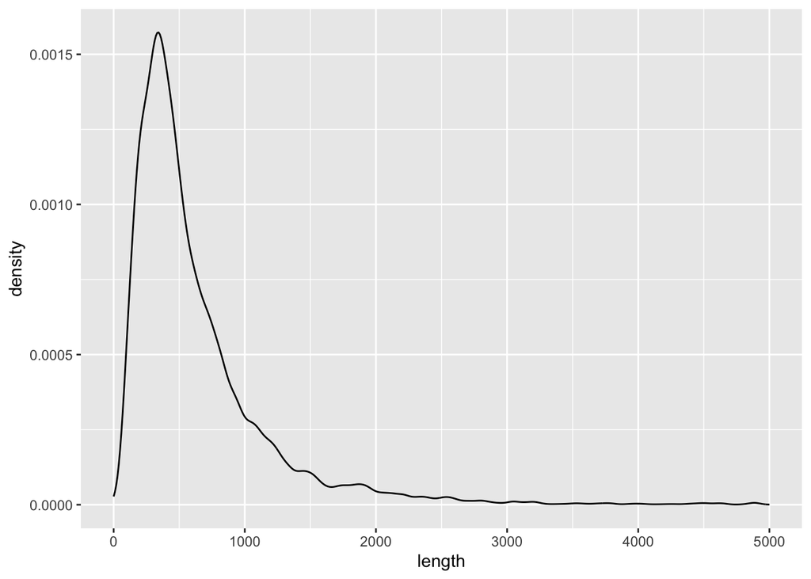

```r
# what is the frequency distribution?
ggplot(prots_sizes, aes(length)) +
  geom_density() +
  xlim(0,5000)
```

Most proteins are *much* longer than 100 amino acids. Thus, finding KDEL as the last four amino acids more than 3% of the time seems inconsistent with the null hypothesis. Some simple queries can provide an immediate additional test.

```r
# how often does KDEL occur near but not at the end?
internal_match <- count(filter(prots, str_detect(prots$sequence, "KDEL.{1}$")))
prop_internal <- internal_match / total_match
print(prop_internal)
```

```
  n
1 0
```

We can easily test other positions by altering the value in the curly braces. Most queries return a proportion of 0 and it’s hard to find a position that approaches 0.01. This supports the notion that there is something special about finding KDEL precisely at the end of a protein. Next week we will learn how to set up a loop that would allow us to systematically test every position.

### Finding consensus sequences in proteins

Many proteins and nucleic acids contain functional components that have a **regular-ish** pattern: some fixed features but also specific kinds of variation. It is possible to define a *consensus sequence* that describes this kind of functional site, including the invariant positions and specific ways in which the variable sites can differ.

```r
# define a regex for the serine protease consensus sequence
str_view(prots$sequence, "[SA]C[QK]GDSGGP[LF]")
```

```
 [1397] │ MFLFCSAGQENINQRIIGGYVTAPYSIKYIVSLKTERGKHFCGGSLISRCWVVTAAHCKAAADQMMIVAGEHSLSALEGTEQHLRPARLYVHPRYNPATKDADIMLIKLRKPALLNRFVSIVALPHQRAVLEDGMICRVSGWGYADNGGGVSSNKLRSVKVPVVPVLQCNSSGSYDGLITANMICAGYGQGGKD<ACQGDSGGPL>TCEGRLFGIVSWGRGCAEAKFPGVYTEVAKFRKWIHKIVFHL
 [3284] │ MLTVLKMILRGLLLVTLVLSVTDAFLPRRHLQHKILHLDWPANCGVSYFQPNTVGRIVSG…<ACQGDSGGPL>LCQVGREKWEVHGVVSFGPIGCTVENKPSVFTRISAYIPWIEATRIRDFFLH
 [3475] │ MAFMFLLFCFAFIGAAFGCGVPAIRPVISGYNKIVNGQNAVSGSWPWQVSLQDGRGFHFC…<SCQGDSGGPL>VCEKNGAWHLVGIVSWGTSNCNVYTPAVYTRVTKFRNWIDQIVASN
 [6448] │ MAPDNCKALDYFIASLVYLITALIYLILLICFILHIKYFSFIIFLISLLPAASMSIEDKI…<SCQGDSGGPL>ACDGELQGVVSWGYDCAMKGHPSVYVKVCRYNTWIHQVMASN
 [8162] │ MKLLCFILMFIAATAFPTQDLHIRTKRGTRFFSDKCMDRETSQIYHHGETWLRFAGTLVE…<ACQGDSGGPL>VCMKDKRMHLIGIVSWGEGCGKKDMPGVYTKVTKYLDWISTTMRL
[12191] │ MWLVLLLSLTPLAGLAAHSFHGEVLSPNFPQGYPNEVERTWNISVPEGFGIELRFTHIDI…<SCQGDSGGPL>VFQDPFKAGHYFVGGIVSWGLECGSLGVYTKVSNYLDWIEKVMKGGEDSKALYRAI
[12686] │ MTELESGLKYVPKAGDMNGFDEKLEFLPVTNPKKLEKSGRRKWYIIGGIVVAALIASLIV…<ACQGDSGGPL>TKFEGNQRGFLAGIVSWGEGCAQKNKPGIYTRVTKFRKWIKDHSGV
[13926] │ MSELQYLPENERPLNPAAVPRTRTNTPKAMISRRKQMTIGIVVVVVAALVVAAVLIKVAL…<ACQGDSGGPL>VYNNNKQWQLVGIVSWGSGCARKNKPGVYCNVEKFLDWIYYVMQQECST
[14998] │ MTWIYPFILFMCLLATVFTECITELHDNIYFQGGDVSAVYAPDVKYCQIVCTYHPQCLFF…<ACKGDSGGPF>VCQYEQTWYLQGITSWGEGCARPDRPGVYTRVGYFKDWILKHV
[15451] │ MKLAVLIWLTSMPCISNSFNSPECGSRPKVDSFGSARIVGGKDATAGAWPWMVSIQMPGW…<SCQGDSGGPL>MCLDEKRDKFIVIGVTSWGRGCARANHPGVYTSTQHFLSWISQVKEQYEEKKKPQKDVPPFAFTQRMIIRLLRAMREAMRRKG
[16587] │ MKLRCSVLLLVLWTLWALFLSAHGTRCGIRPIAGPPTDSRVIGGENALAGHWPWQVSIQV…<SCQGDSGGPL>ACYDDNEGKFFLVGITSFGYRCAQPHFPGVYTRVSNYNHWVNHLLENGNSAIAGASRNVFFTLIFTFGGKFFFH
[17061] │ MKRLLQALYVFITLFVLLIPGDESVEIIGGHEVTPHSRPYMALIQHVRNKKSICGGTLIK…<ACQGDSGGPL>ICNNELRGITAFGKGCGLPDKPGVYTRLTKKYFQWIQKITGRQSLNETNIDF
[17175] │ MKTDGFVEIGFFIRNSVSVEIIGGHEAKPHSRPYMALIEDAKGKPFCGGTLIKANWVLTA…<SCKGDSGGPL>ICKKQLSGITSFGPKCGTFKKPGIYTRLTENYVLWIQKKLQELDNKYDN
[19962] │ MTAIIWAFLLPLLLYTVSGNRLQEYERTTGAWIYDPQMKDYSVNTVEECAVKCNTETEFV…<SCQGDSGGPL>VCYDEEKYIIQGVTSWGLGCAEPMKPGVYVRVSSFISWIEQTMENN
[20926] │ MSVHYSCTGKFRCTTSPKCIEPSARCDGVKDCGTGEDEYGCVRLSGKNSVLQIYSAGSWR…<SCQGDSGGPL>ACQGTSNWKLIGATNWGYGCAQKKKPGVYVRVTAYLDWIHEKMEVCGYSKSEHTVLLKGSSCLGFLLSTRKSRVAPVA
[20936] │ MAEKVPCSPFYSLRLNESNDVTKNAQLNSVNRELQKSQLTIFDGIGLMETFKMTITDFAL…<SCQGDSGGPL>VTQQHSSWWLVGVTSWGEGCARRNRPGVYGKVTELLDWIYLTMQAN
[20951] │ MQQSIQEGDQFLDEILETMQGCSAWIVKDQFFFLLLLFLFQVSNISVYVLPIEEKLSKRR…<ACKGDSGGPL>SCQMKGSGRWFLNGIVSWGYGCGRPNFPGVYTKVSKFSSWIEKHVPTFS
[20952] │ MQDVVKSLKSVFILDPPKSVNTRVRSQLRKRSMTQCKVCDHNNSGKGCSGLTTEASGSKE…<ACQGDSGGPL>ACLGKGNKWFLAGIVSWGEGCGRRNRPGVYTHVSTFYNWIQQQMN
[25053] │ MSSLVVLAVALLASAGLCCPDAGSPFPPHHLGCLRNKSSLGCFGGSRNLTESGEKCLRWT…<SCQGDSGGPL>MCERPGGSWVVFGVTSWGYGCGVQDSPGVYTKVSSFVSWIKRVTEL
[26023] │ MRRRRAVRGGAYEKEKGCEGRSYEKEKGCEGRSYEKEKGCEGRSYEKGKGCERRKGRSYE…<ACKGDSGGPF>VCKRASGIWTLMGITSWGMGCARSWGDQYNQTEERGTPGVYSRVAYLMDFIHQYVTMGKV…
... and 17 more
```

```r
# examine the description
query <- filter(prots, str_detect(prots$sequence, "[SA]C[QK]GDSGGP[LF]"))
query$description
```

```
 [1] " trypsin "
 [2] " chymotrypsin-like elastase family member 1 "
 [3] " chymotrypsin-like protease CTRL-1 "
 [4] " trypsin-like "
 [5] " tissue-type plasminogen activator "
 [6] " complement C1s subcomponent "
 [7] " suppressor of tumorigenicity 14 protein homolog "
 [8] " transmembrane protease serine 4a "
 [9] " plasma kallikrein "
[10] " acrosin-like "
[11] " transmembrane protease serine 12-like isoform X1 "
[12] " granzyme A-like "
[13] " granzyme A-like "
[14] " plasminogen "
[15] " transmembrane protease serine 3 "
```

[output cut: 22 more lines]

Many descriptions are consistent with serine proteases: trypsin, chymotrypsin, plasminogen, complement, etc.

**Finding phosphorylation sites** Many proteins are phosphorylated and de-phosphorylated to regulate their function. The consensus sequence for phosphorylation is: **arg-arg/lys-polar-ser/thr** where polar is any amino acid with a polar side-chain. Compared with the consensus sequence of a serine protease, the phosphorylation site is shorter but more ambiguous: instead of at most 2 options per site, there are 12 options at one site.

```r
# define the search string
#str_view(prots$sequence, "R[RK][RHKDESTNQCGP][ST]")     # warning: takes 30-90 sec
```

Were you surprised by how long this search took? In general, searches take increasing amounts of time in this order: any character, either of 2 characters, any of a few characters, any of a large set of characters. The overall length of the search pattern has much less impact on search time.

**Finding zinc-finger transcription factors.** The genome of every organism contains genes that encode *transcription factors*, proteins that regulate gene expression. Several families of transcription factors have evolved independently, each with a distinct structure and DNA-binding domain. In vertebrates, one of the largest families of transcription factors are *zinc-finger proteins*, which contain the DNA-binding motif **tyr/phe-X-cys-X-cys-X-X-(X)-(X)-cys-X-X-X-phe-X-X-X-X-X-leu-X-X-his-X-X-X-(X)-his** where X is any amino acid and (X) may or may not be present.

In the code below, note the use of the `regex()` function to store a search pattern as a regex object. We can then pass that object to any `stringr` function. (If you store a simple string and then pass it to a `stringr` function, it won’t work.)

```r
# start by constructing a regex to find zinc-finger motifs
str_view(prots$sequence, "[YF].C.{2,4}C.{3}F.{5}L.{2}H.{3,4}H")
```

```
 [102] │ MAALKVETGGGFLQSTNSSTNQDSQPSPLALLAATCSRIESPNENANSQGQNQELQQGST…<FVCTWMFCGKRFTRSDELQRHKRTH>TGEKK<FVCPECPKRFMRSDHLSKHIKTH>MNKKVNPTNSVISLSASADSGSTPENTVATAAAPTPTALISAGSMVTMEAISPEGIARLANSGINVMQVTDLQPINISGNGF
 [215] │ MAASMLEEETRYGSSPLAMLTAVYNKFGGSSPIRDSATPGKTGNNSGKKPCNLNSDLSIP…<FVCNWLFCGKRFTRADELERHLRTH>TREKK<FTCLLCNKRFTRSDHLSKHQKTH>TEASGVKAPNEGEVDREEPTVSGSPSNGIQEVINNEDKSTTSPEQGGLLEI
 [221] │ MATLAVPRGENILQSFLQDRTPSSSPESASHPSLAFLATTCGQVRQGGPSHSELSQLSYE…<FVCSWYFCGKSFTRSDELQRHLRTH>TGEKR<FCCQECGKRFMRSDHLSKHVKTH>QNKKSKLSDTVLDNIKKE
 [229] │ MEFPDHSRQLLQCLSQQRHQGFLCDCTVLVGEAQFRAHRAVLASCSMYFHLFYRDQLDKR…<YTCGQCGKSFQYSHNLSRHAVVH>TREKPHACKWCERRFTQSGDLYRHIRKFHCGLVKSLAI
 [237] │ MTSRFKMPRPSHSDYVLQQLSNQREWGFLCDCCIAIDDIYFQAHKAVLAACSSYFKMLFI…<FVCQICGKQFLRERQLRLHNDMH>KGMARYICPMCDQGNFRKHDHVRHMISHLSAGETICQICFQIFPNNEQLEQHMDVHLYICGVCGAKFSLRKDMRSHYNAKHLKRT
 [238] │ MTSRFKMPRPSHSDYVLQQLSNQREWGFLCDCCIAIDDIYFQAHKAVLAACSSYFKMLFI…<FVCQICGKQFLRERQLRLHNDMH>KGMARYICPMCDQGNFRKHDHVRHMISHLSAGETICQICFQIFPNNEQLEQHMDVHLYICGVCGAKFSLRKDMRSHYNAKHLKRT
 [239] │ MTSRFKMPRPSHSDYVLQQLSNQREWGFLCDCCIAIDDIYFQAHKAVLAACSSYFKMLFI…<FVCQICGKQFLRERQLRLHNDMH>KGMARYICPMCDQGNFRKHDHVRHMISHLSAGETICQICFQIFPNNEQLEQHMDVHLYICGVCGAKFSLRKDMRSHYNAKHLKRT
 [383] │ MTKIPPKRRGIKFEVGAQLEARDSLRNWYTANIEKINYEEGKVLIHFKHWSHCHDEWFYW…<FRCKILDCSKSFRKAKLLHYHMKYFH>GVEKLPDLEQSPVKRSIETRGSSALKKQAIQDSSRRRRTTSGSSHTALHMAQRNFPSSPT…
 [384] │ MTKIPPKRRGIKFEVGAQLEARDSLRNWYTANIEKINYEEGKVLIHFKHWSHCHDEWFYW…<FRCKILDCSKSFRKAKLLHYHMKYFH>GVEKLPDLEQSPVKRSIETRGSSALKKQAIQDSSRRRRTTSGSSHTALHMAQRNFPSSPT…
 [385] │ MTKIPPKRRGIKFEVGAQLEARDSLRNWYTANIEKINYEEGKVLIHFKHWSHCHDEWFYW…<FRCKILDCSKSFRKAKLLHYHMKYFH>GVEKLPDLEQSPVKRSIETRGSSALKKQAIQDSSRRRRTTSGSSHTALHMAQRNFPSSPT…
 [386] │ MTKIPPKRRGIKFEVGAQLEARDSLRNWYTANIEKINYEEGKVLIHFKHWSHCHDEWFYW…<FRCKILDCSKSFRKAKLLHYHMKYFH>GVEKLPDLEQSPVKRSIETRGSSALKKQAIQDSSRRRRTTSGSSHTALHMAQRNFPSSPT…
 [946] │ MATAAYVDHFAAECLVSMSSHPIVHGPKGNLETKQDAAPPSINGEDKKEVKETLMKENASLFVVAGILAGLNQHIPIPDQSTQTDNADIIDKSIPPNKDAWSESGSLTGKRGGKAATPTVPSEPSPKQRSKRGRSKTDSESPQKKHKCHYAGCEKVYGKSSHLKAHLRTHTGERP<FPCTWEGCNKKFARSDELARHYRTH>TGEKK<FSCPICEKRFMRSDHLMKHARRH>ANFHPSMLKRPHGSSSRTGSVSDYSRSDPSSPTISPASSP
[1654] │ MPRGFLVKRSKKASVSYRIRTDQEDELLCKALSKPSETQMIVYPYNPASAFQENGLNWYS…<YRCPECDKVFSCPANLASHRRWH>KPRPGTTAESQNHKKQQLPTITDHVNVSIEGKENSSKPLASDYQQESKGSSHCPDQHHHTMNSSQHLHENCKTVDNVQLLDQHHVTVNSSNLLDQNNKPTENSQYQDRRPTVSTLTSMQGGTEDF<FECPYCCKKFRRQAYLRKHLAAH>EVTRPMSYSQPDRRQLTFPCHLCGAHFPSAEIRDKHRVWHTVKEEILINHGKESS…
[1907] │ MLLAQINRDSQGMAEFQGGVDAQHVTLCLAEAVAVADGEQLENMDGVSLQAVTLADGSTA…<YQCEHPSCGKAFATGYGLKSHVRTH>TGEKP<YHCTVEKCTKSFKTSGDLQKHIRTH>TGERPFKCPFEGCGRSFTTSNIRKVHIRTHTGERPYYCAEPGCGRAFASATNYKNHVRIHTGEKP<YVCTVPGCDKRFTEYSSLYKHHVVH>THSKPYNCNHCGKTYKQISTLAMHKRTAHNDTEPVEEEQEAFFEPQPVSSSEEILKGQQI…
[1908] │ MLLAQINRDSQGMAEFQGGVDAQHVTLCLAEAVAVADGEQLENMDGVSLQAVTLADGSTA…<YQCEHPSCGKAFATGYGLKSHVRTH>TGEKP<YHCTVEKCTKSFKTSGDLQKHIRTH>TGERPFKCPFEGCGRSFTTSNIRKVHIRTHTGERPYYCAEPGCGRAFASATNYKNHVRIHTGEKP<YVCTVPGCDKRFTEYSSLYKHHVVH>THSKPYNCNHCGKTYKQISTLAMHKRTAHNDTEPVEEEQEAFFEPQPVSSSEEILKGQQI…
[1950] │ MEYLMEAETQTDPVVVLSLAQAAILGLVSQTELFGATVKTNGFHLPTDCGFEVSSFVLPD…<YSCRFCSRGFAYPSELKSHEAKH>QSGRCHVCVECGLDFATLTQLKRHLTAHQGPTP<YQCAECNKSFHYRSQLQNHMLKH>QNIRP<FVCTECGMEFAQVHHLRQHSLTH>KGVKEFKCEVCGREFTLQANMKRHMLIHASVRP<YQCHICFKTFVQKQTLKTHMIVH>SPVKP<FKCKVCGKMFNRMYNLLGHMHLH>AGSKP<FKCPYCSSKFNLKGNLSRHMKIK…
[2025] │ MALSGTILPSFATFANHRERGYDKWRSDGTGKPSSTSCSMVETMNSMNNYSSRKDEEDLK…<YHCNWEGCGWKFARSDELTRHYRKH>TGHRP<FQCHLCERAFSRSDHLALHMKRH>M
[2069] │ MSHHYEPWFRSSHPNSSNEDGSTPLWWDLHAGSSWMDFPHNQGGLQSPTNPSGLQTSLGSYASDHQLCGPPSHLLPSNQHLVAQDGFKQLESIQESPSFDQTQDGAARPKGSRRSVPRSSGQAACRCPNCLEAERVGTCTDGTRKKHLHNCHIPGCGKAYSKTSHLKAHLRWHSGDRP<FVCNWLFCGKRFTRSDELQKHLQTH>TGTKK<YSCHMCTRVFIRVDHLNKHMKTH>EGARDGAESENKGTPASLEPPLKGSRDPEGIASCSGQPN
[2241] │ MTMLLDSGPQFPSLGVSGFGTPRHPDMPNRDTGLGFNPFGDSSHTAAFKLPATHEISSSQ…<FPCPFPGCGKIFARSENLKIHKRTH>TGEKPFKCEFEGCDRRFANSSDRKKHMHVHTSDKPYICKVCDKSYTHPSSLRKHMKVHESQSSDSSPAASSGYESSTPPVLASANSEDITKTPPSVVQNSTSHNPGLPPNFNEWYV
[2368] │ MPTHPLLVYLDSPDGLASSFGPRIEHTESTMSICTNITSYRNIQEKAAIQTEECIPLDQPFKHHEDLSQQMLTQNECEPAILKVKGKPLNPVQKGEMKMGSPSEVDSKMENEKLCCEVCGHTLDDALDLETHMKKHKDSFI<YWCNVCGRRFKEPWFLKNHMRTH>TGKTGSKNKPQQDSETPTTINDVLQESATTNVTSPYKMCMVCGFLFQNKETLFEHSKVHN…
... and 691 more
```

```r
# how many proteins contain at least 1 zinc finger?
znfinger <- regex("[YF].C.{2,4}C.{3}F.{5}L.{2}H.{3,4}H")
prots_plusZ <- mutate(prots, zf_count = str_count(prots$sequence, znfinger))
query <- filter(prots_plusZ, zf_count > 0)
nrow(query)
```

```
[1] 711
```

```r
# are they annotated as zinc-finger proteins?
query$description[1:40]          # limiting the output because there are so many
```

```
 [1] " transcription factor Sp1 "
 [2] " transcription factor Sp7 "
 [3] " sp5 transcription factor-like "
 [4] " zinc finger and BTB domain-containing protein 18.2 "
 [5] " zinc finger and BTB domain-containing protein 1 "
 [6] " zinc finger and BTB domain-containing protein 1 "
 [7] " zinc finger and BTB domain-containing protein 1 "
 [8] " PHD finger protein 20b isoform X1 "
 [9] " PHD finger protein 20b isoform X1 "
[10] " PHD finger protein 20b isoform X2 "
[11] " PHD finger protein 20b isoform X3 "
[12] " Krueppel-like factor 13 "
[13] " insulinoma-associated protein 1 "
[14] " zinc finger protein 143 isoform X1 "
[15] " zinc finger protein 143 isoform X1 "
```

[output cut: 25 more lines]

Most of these are zinc finger proteins, but it’s not always obvious from the names. The following are some of the many names for sub-families of zinc finger proteins: Sp7, Kreuppel, Wilm’s tumor protein, and PHD finger protein.

Most zinc-finger proteins contain multiple DNA-binding motifs. We can do some exploratory data analysis to figure out how many zinc fingers are present.

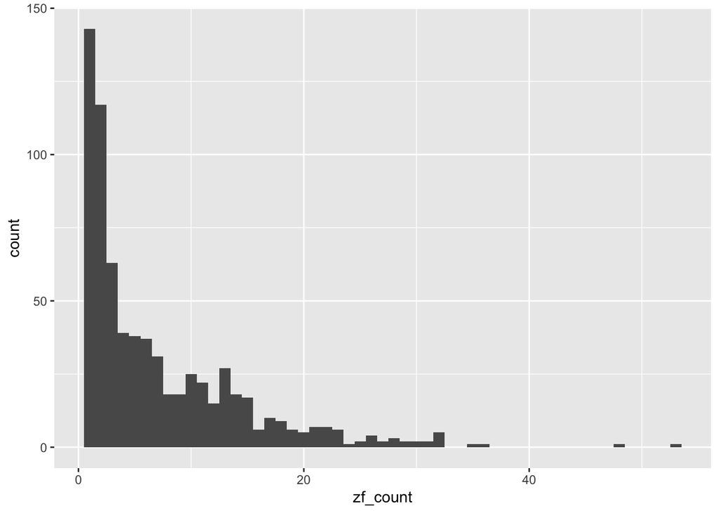

```r
# plot the frequency distribution of zinc fingers
ggplot(query, aes(zf_count)) +
  geom_histogram(binwidth=1)
```

Some proteins contain *a lot* of zinc-fingers! We can ask where there is a relationship between protein length and the number of zinc fingers it contains.

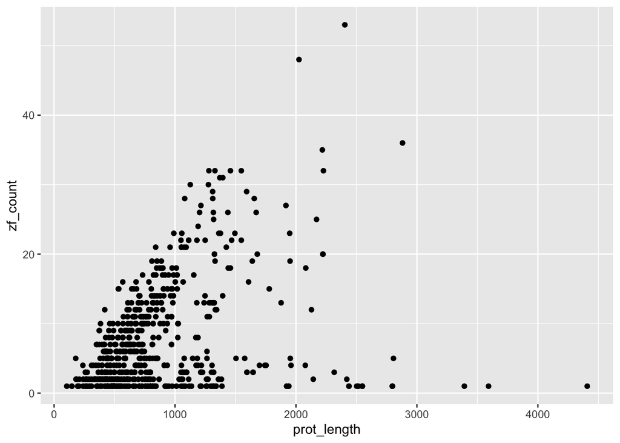

```r
# do longer proteins tend to have more zinc fingers?
query <- mutate(query, prot_length = str_length(query$sequence))
ggplot(query, aes(x = prot_length, y = zf_count)) +
  geom_point()
```

This distribution suggests that there might be two distinct classes of zinc finger proteins: one where length is correlated with the number of zinc fingers and another where it is not.